# Doctoral Admission

### Table of Contents

These guidelines are meant to help you in taking the next step in your career. The steps outlined below require a great deal of organization and advanced planning. Your faculty and recommenders want to help you reach your goals. Deviation from the steps below can hurt that process.

1. Letters of Recommendation
2. Prospective Programs
3. Professional Material

### 1. Letters of Recommendation (LOR)

Requesting an LOR is a big step. Ideally, you have known the person beyond a classroom setting. Regardless, this step is the most critical because your behavior has a direct effect on another person who wants to help you but also has a busy schedule of their own. The steps below can increase your odds of success but require a good deal of rigor and planning on your part.

**1a. Get Organized with a shared Google Sheet** – The application process requires a great deal of organization and anticipation. An ideal situation is for you to *share* with Dr. Bedics (not email) a Google Sheet that lists all your schools, their deadlines, and whether or not you received a confirmation email that the LOR was received. Here’s a doctoral example for a Google Sheet:

[figure not shown]

It is easier to use a Google Sheet than an imported Excel. As an option, you could add more information to share such as the admission ratio, average GREs for admission, or other tasks that help you track what you need (i.e., submitted transcripts etc.). Revise this to fit your needs. The ideal situation is for you to have this **complete by 10/15**. Late additions are risky and I would resist the urge to continually add programs.

**1b. Due Dates (Doctoral/Internship)** – You should submit all of your LOR requests 1-month prior to the earliest deadline. For example, if you have a 11/15 deadline then all your email requests should be sent to the recommender by 10/15. This requires that you have your full list well in advance (10/15) and are able send out email requests early.

- The latest an email request can be sent to Dr. Bedics is 11/1. If you miss this then Dr. Bedics cannot guarantee a timely submission.

**1c. Send all school requests at once** – There can be nothing worse for a recommender than to receive random email requests to submit a letter for student throughout the course of semester. The solution is to send all the LOR in one batch and at the same time. Such an approach is not only considerate of your recommender but will also increase the likelihood that no school will be missed. It also forces you to get organized.

**1d. Minor Points:**

- **Electronic Submissions (Doctoral)** – The best and easiest way for recommenders to submit letters is through an online web portal that is sent via an email from the university. Students can sometimes lack clarity on how to submit for each school. Please do your research.
- **Waive Your Rights** – You should waive your rights to read the letter. Not doing so can be perceived as odd. In the end, it is your choice.
- **No Snail Mail** – Although unlikely, check to see if any of your schools require actual physical letters. You will need to provide the recommender with a stamped, addressed envelope, with no return address.
- **LOR to Student** – There should never be a situation where you have to collect the LOR from the recommender. To ask for such a thing can be perceived as odd and shows that you likely did not do you HW on how to send a LOR to a school.

**1e. Thank You Cards** – A standard form of etiquette is to send a thank you card. Not an email but a physical card. Your recommenders are likely old enough to appreciate a printed and written thank you card. I would resist the urge to send gift cards (e.g., Starbucks cards). The sentiment in the card is more than enough and you’ll stand out.

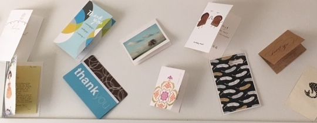

Jamie’s much appreciated wall of thank you cards (much fewer than actual letters written)

Go to top

### 2. Prospective Programs

The best thing you can do to improve your chances of admission is to apply broadly across a number of criteria. As noted above, typical criteria include:

- Applicant/Acceptance Ratio
- Average or Minimum GRE Scores
- Average or Minimum GPA
- Faculty Fit (PHD Programs)
- School Mission Fit (PSYD Programs)
- Funding Available (Full or Partial Tuition Remission and/or Stipends)

Do what you can to quantify the above factors and fit them into your Excel. You can then do your best to assess the breadth of your options. I would assign each school to one of three tiers (reach, middle, easy) based on your own personal sorting. Lastly, make sure you have representation in all tiers. In my experience, students either severely overestimate or underestimate themselves. Such a ranking can help see where you might have holes.

I recommend doing your best to include traditional universities and colleges rather than free-standing programs regardless of profit status.

### 3. Professional Material

Feel free to share with me your personal statement, CVs, or other material on a Google Drive preferably where you shared your Google Sheet. I provided example CVs and an excellent personal statement for doctoral programs in the MS Clinical folder. You can access the folder through Blackboard. My general rule is that I provide feedback **once** on all material.

Go to top